# Week_9

## *Or, technically week 8, part II*

### First let’s load the libraries we’ll need:

```r
library(dplyr)
library(ggplot2)
```

**Note:** to hide the output of these two commands, add `message=FALSE` to the curvy brackets with `{r}`. Press the “run current chunk” button, *not* Ctrl-Enter.

#### Loading the data frame:

```r
parentage_data <- read.csv("../data_8/parentage_with_phenotypes_CSV.csv")
```

### Next, we’ll manipulate the data:

```r
#Filtering out NAs and blanks by selecting sex columns only with m or f
filtered_parentage_data <- parentage_data %>%
  select(sex, length, depth, sex.1, length.1, depth.1, sex.2, length.2, depth.2) %>%
  filter(sex == "m" | sex== "f") %>%
  filter(sex.1 == "m" | sex.1 =="f") %>%
  filter(sex.2 =="m" | sex.2 == "f") %>%

#Creating length:depth ratio columns for offspring and each parent
  mutate(LD_ratio = length/depth) %>%
  mutate(LD.1_ratio = length.1/depth.1) %>%
  mutate(LD.2_ratio = length.2/depth.2) %>%
  na.omit() #ensuring all NAs are removed
```

##### *Notice a pipe was used for this entire chunk*

#### Let’s see what we’ve done so far:

```r
head(filtered_parentage_data)
```

```
##   sex length depth sex.1 length.1 depth.1 sex.2 length.2 depth.2 LD_ratio
## 1   f    388    90     m      400     116     f      428     111 4.311111
## 2   f    398    99     m      400     116     f      428     111 4.020202
## 3   f    425    94     m      462     157     f      447     114 4.521277
## 4   m    395   109     m      400     103     f      387     111 3.623853
## 5   m    415   128     m      431     124     f      410      91 3.242188
## 6   f    418   104     m      432     137     f      409      99 4.019231
##   LD.1_ratio LD.2_ratio
## 1   3.448276   3.855856
## 2   3.448276   3.855856
## 3   2.942675   3.921053
## 4   3.883495   3.486486
## 5   3.475806   4.505495
## 6   3.153285   4.131313
```

```r
View(filtered_parentage_data)
```

### Next we’ll be calculating the **z-scores** of the parents and offspring.

#### A z-score is the distance of a value from the mean in terms of standard deviations. Statistically, values with z-scores greater than 2 (more than 2 standard deviations from the mean) are considered unusual.

#### Before we can calculate z-scores, though, we need the mean and standard deviation of the length:depth columns.

```r
#standard deviations
sd_dad <- sd(filtered_parentage_data$LD.1_ratio)
sd_mom <- sd(filtered_parentage_data$LD.2_ratio)
sd_offspring <- sd(filtered_parentage_data$LD_ratio)

  #means
mean_dad <- mean(filtered_parentage_data$LD.1_ratio)
mean_mom <- mean(filtered_parentage_data$LD.2_ratio)
mean_offspring <- mean(filtered_parentage_data$LD_ratio)
```

#### Now for the z-scores, featuring a fancy for loop

```r
#z-scores
    #dad
for (i in seq(1, length(filtered_parentage_data$LD.1_ratio))) {   #establishing the data to which the loop will apply (the dad length:depth (LD.1) ratio column)
  z_score_dad <- (filtered_parentage_data$LD.1_ratio[i] - mean_dad)/ sd_dad   #i is used as a generic variable. We're subtracting each entry in LD.1_ratio from the mean and dividing that difference by the standard deviation
  filtered_parentage_data$z_score_dad[i] <- as.numeric(z_score_dad)  #assigning the results of the above line to the column "z_score_dad"

}

    #double check that it worked properly...
head(filtered_parentage_data$z_score_dad)
```

```
## [1] -0.08279160 -0.08279160 -2.49565180  1.99418987  0.04859165 -1.49056754
```

```r
(filtered_parentage_data$LD.1_ratio[1] - mean_dad)/sd_dad # If the loop worked correctly, this should yield the same value as the first output value from the loop
```

```
## [1] -0.0827916
```

```r
    #mom
for (i in seq(1, length(filtered_parentage_data$LD.2_ratio))) {
  z_score_mom <- (filtered_parentage_data$LD.2_ratio[i] - mean_mom)/ sd_mom
  filtered_parentage_data$z_score_mom[i] <- as.numeric(z_score_mom)

}
head(filtered_parentage_data$z_score_mom)
```

```
## [1] -0.37144982 -0.37144982 -0.09387941 -1.94401240  2.39433833  0.80128901
```

```r
    #offspring
for (i in seq(1, length(filtered_parentage_data$LD_ratio))) {
  z_score_offspring <- (filtered_parentage_data$LD_ratio[i] - mean_offspring)/ sd_offspring
  filtered_parentage_data$z_score_offspring[i] <- as.numeric(z_score_offspring)

}
head(filtered_parentage_data$z_score_offspring)
```

```
## [1]  0.28482151  0.12709609  0.39876926 -0.08779674 -0.29472868  0.12656950
```

##### *These all look like reasonable z-scores!*

### Now that we have the z-scores filled out, let’s graph them to see if there are any correlations.

#### More specifically, We’ll make scatter plots for mom z-score vs. ofspring z-score and dad z-score vs. offspring z-score.

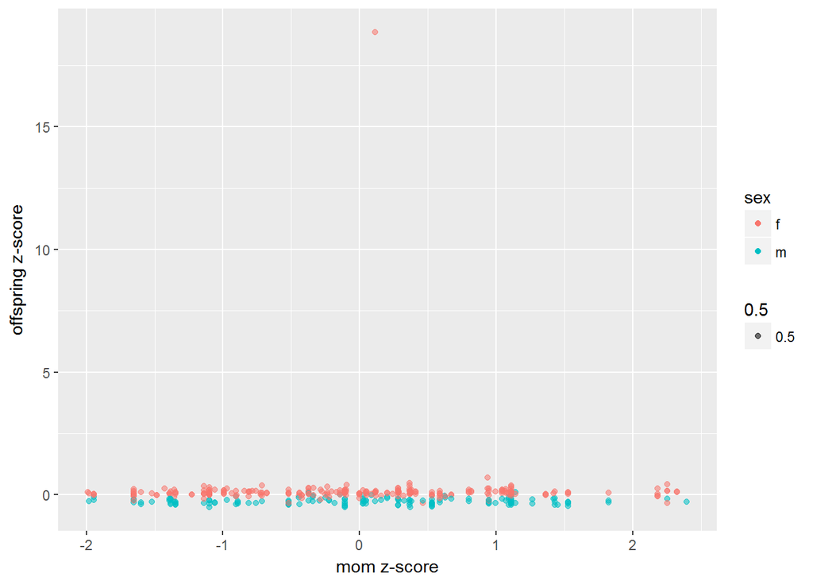

```r
##graphing z-scores to compare between offspring and each parent
    #mom and offspring
ggplot(data = filtered_parentage_data) +
  geom_point(mapping = aes(x = filtered_parentage_data$z_score_mom, y = filtered_parentage_data$z_score_offspring, color = sex, alpha = 0.5))+
  labs(x = "mom z-score", y = "offspring z-score")
```

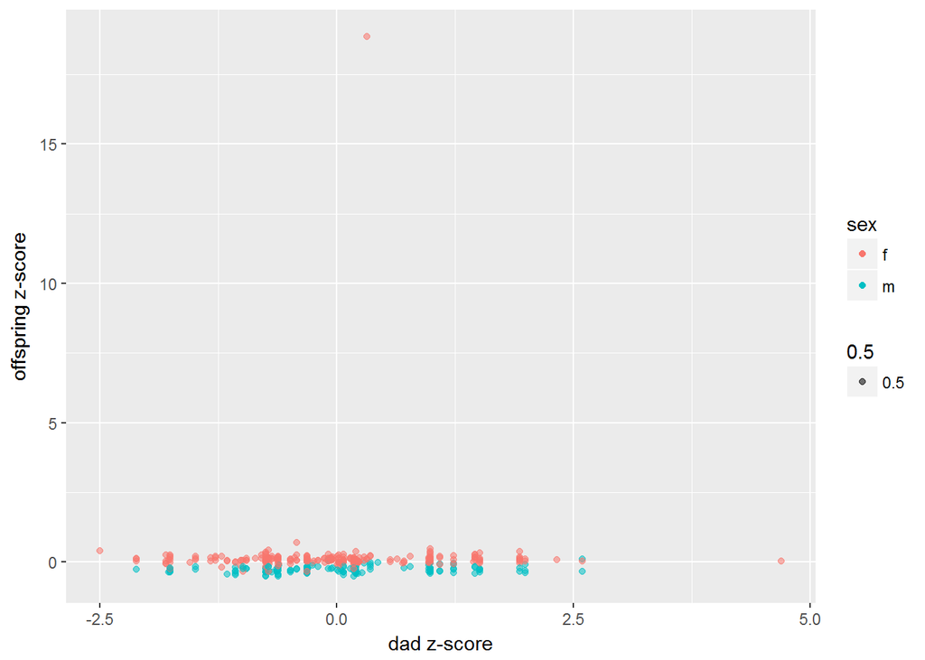

```r
  #dad and offspring
ggplot(data = filtered_parentage_data) +
  geom_point(mapping = aes(x = filtered_parentage_data$z_score_dad, y = filtered_parentage_data$z_score_offspring, color = sex, alpha = 0.5))+
  labs(x = "dad z-score", y = "offspring z-score")
```

#### We can see that there’s one obvious outlier in both plots throwing off the scale and obscuring any trends that may be there. Let’s fix that (and also take out that “0.5” legend that makes no sense):

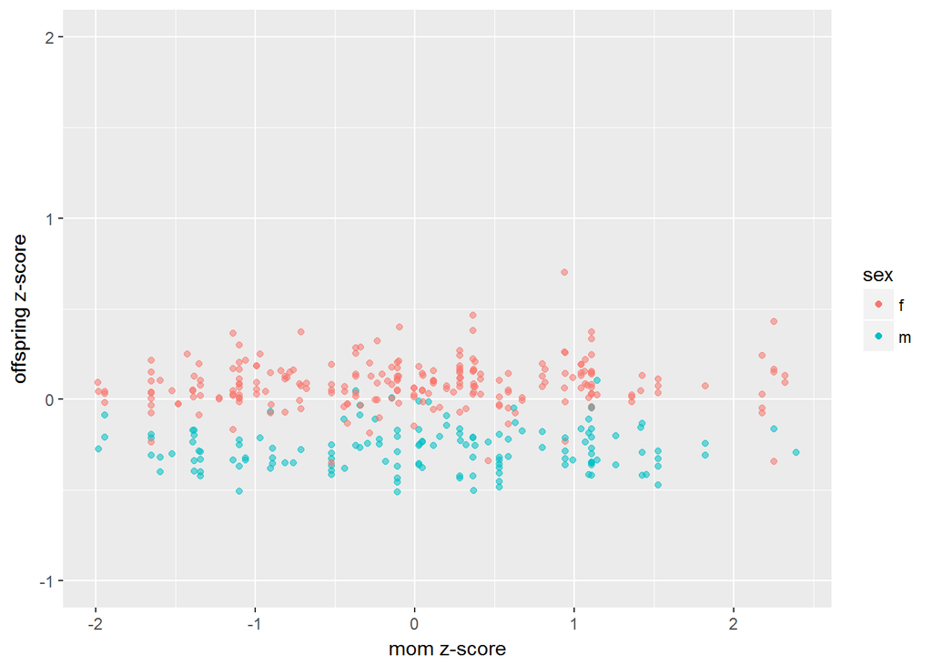

```r
#mom and offspring - outlier removed
  ggplot(data = filtered_parentage_data) +
  geom_point(mapping = aes(x = filtered_parentage_data$z_score_mom, y = filtered_parentage_data$z_score_offspring, color = sex, alpha = 0.5))+
  labs(x = "mom z-score", y = "offspring z-score") +
  ylim(-1, 2)+
  guides(alpha = FALSE)
```

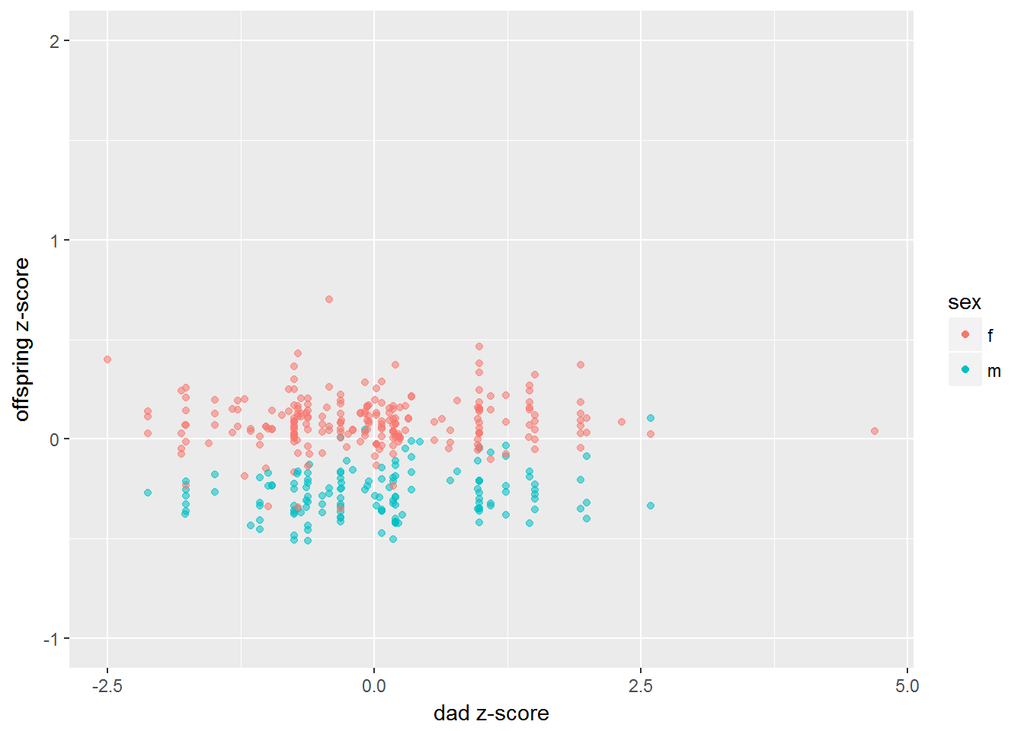

```r
  #dad and offspring - outler removed
  ggplot(data = filtered_parentage_data) +
    geom_point(mapping = aes(x = filtered_parentage_data$z_score_dad, y = filtered_parentage_data$z_score_offspring, color = sex, alpha = 0.5))+
    labs(x = "dad z-score", y = "offspring z-score")+
    ylim(-1,2)+
    guides(alpha = FALSE)
```